# Resource availability and species invasion

Romain

This report aims to explore the effect of resource availability on the success of species invading an ecosystem.

The ecosystem and invading species are simulated using the mizerEvolution R package.

At the end of every simulation, all species are assigned a survability score, designed to compare the species.

### How species invade

Simulations are trait based models starting with 9 natives species, their only difference being their asymptotic size (and by extension their maturation size). Asymptotic size range from 6.3 g to 10000 g and are evenly spaced across a logarithmic scale.

Such default simulation is obtained with:

```r
params <- evoParams(no_sp = 9)
```

```r
sim <- evoProject(params = params, mutation = 0, alien = 5, t_max = 3000)
```

Such simulation time and invasion chance were chosen to have simulations long enough for invader to settle and remove native species without having hundreds of invasion which would slow down the computation time.

When an invasion event occurs, a new species is introduced in the ecosystem following these rules:

1. Its trait values are randomly drawn from statistical distribution following this table.

|  | distribution | var1 | var2 |
| --- | --- | --- | --- |
| w_inf | lnorm | 6.7648459 | 2.252483e+00 |
| beta | uform | 10.0000000 | 4.000000e+05 |
| sigma | uform | 0.8000000 | 3.200000e+00 |
| k_vb | uform | 0.1000000 | 1.000000e+00 |
| ks | uform | 2.8000000 | 1.300000e+01 |
| eta | norm | 0.1207153 | 1.148086e-01 |

Values were extrapolated from the North Sea parameters present in Mizer. For lognormal distribution, var1 is meanlog and var2 is sdlog. For uniform distribution, var1 is minimum value and var2 is maximum. For normal distribution, var1 is mean and var2 is sd.

Beta values are converted to log10 for the uniform distribution to supress a bias towards picking high values. Eta values have to be higher than 0.027 (lowest in North Sea). W_inf cannot be higher than the highest original value in the ecosystem.

2. Rmax is determined from asympotic size and kappa:

$$R_{max} = \kappa w_{inf}^{-1}$$
3. The initial abundance per size class of the invading species is calculated as follow:

$$n_{init.w} = w_{inf}^{(2n - q - 2 + 0.35)} . w^{(-n - 0.35)}$$
Which is the same way as when initialising an ecosystem with Mizer. This default size spectrum of abundance can be scaled up and down if necessary using the alien_init_n argument, in this case it was not.

### Survival score

Determining the success of an invasive species was judged over three criteria.

- Did it survive until the end of the simulation
- How much biomass does it have compared to the community
- How much reproduction output does it have compared to the community

Below is the function calculating the scores:

```r
survivalDiag <- function(sim)
{

# length of survival per species
survivalLength <- sim@params@species_params$ext - sim@params@species_params$pop # negative values means the species was still alive at the end of the sim
names(survivalLength) <- sim@params@species_params$species
survivalRank <- sort(survivalLength) # this sort put all the surviving species first, then the extinct ones (but in inverted order)
survivalRank <- c(survivalRank[which(survivalRank <0)],survivalRank[rev(which(survivalRank >= 0))]) # now they are in the right order, need to assign weights

# for now, you get 1 if you survived and 0 if you didn't
survivalRank[which(survivalRank >= 0)] <- 0
survivalRank[which(survivalRank < 0)] <- 1
survivalRank <- survivalRank[order(as.numeric(names(survivalRank)))]

# add a bonus for number of years survived compared to total length
# first need to correct negative values for species still existing
survivalLength[which(survivalLength < 0)] <- dim(sim@n)[1] + survivalLength[which(survivalLength < 0)]
survivalLength <- survivalLength / dim(sim@n)[1]

# adding length survived and survived until end
survivalRank <- .15*survivalRank + survivalLength # assuming that reaching end of sim gives a bonus of .15 (because good species arriving at a late stage of the sim would get a bad score for not surviving long)

# doing different order because don't know which one I pref

# % of total community biomass per species
biom <- getBiomass(sim)[dim(sim@n)[1],]
biomFrac <- biom / sum(biom)
biomRank <- sort(biomFrac, decreasing = T)

# % of total energy allocated to reproduction per species
reproFrac <- getRDI(sim@params) / sum(getRDI(sim@params))
reproRank <- sort(reproFrac, decreasing = T)

# Ranking species with the 3 previous indexes
# Native species will have a fixed rank and invasive species will be put around or maybe not
sparams <- sim@params@species_params
colorRank <- (survivalRank + biomFrac + reproFrac)/3
names(colorRank) <- sim@params@species_params$name

# how many natives species
no_native <- length(which(sim@n[1,,1]>0)) # species with positive abundance at sim start
symbol = c(rep("native",no_native), rep("invasive",(dim(sparams)[1]-no_native)))
label = c(sparams$name[1:no_native],rep(NA,(dim(sparams)[1]-no_native)))


plot_dat <- data.frame(species = sparams$name, beta = sparams$beta,
                       sigma = sparams$sigma, w_inf = sparams$w_inf,
                       w_mat = sparams$w_mat, k_vb = sparams$k_vb,
                       ks = sparams$ks, R_max = sparams$R_max,color = colorRank,
                       Origin = symbol, label = label)

return(plot_dat)
}
```

### Kappa scenarios

To explore the effect of kappa on the species invasion success, 10 simulations were run for 9 different value of kappa (0.0005, 0.001, 0.005, 0.01, 0.05, 0.1, 0.5, 1, 5).

The simulation were then grouped per kappa values for plots. Native species were identical across simulation. However, depending on the success of invading species, native species did not have the same survival score across any two simulations. In that regard, survival scores of the native species within simulations of same kappa were averaged to present only one value.

### Results

Invaders have randomised traits value over 6 parameters, therefore one way to find patters is to examine the survival score of the species versus their trait value.

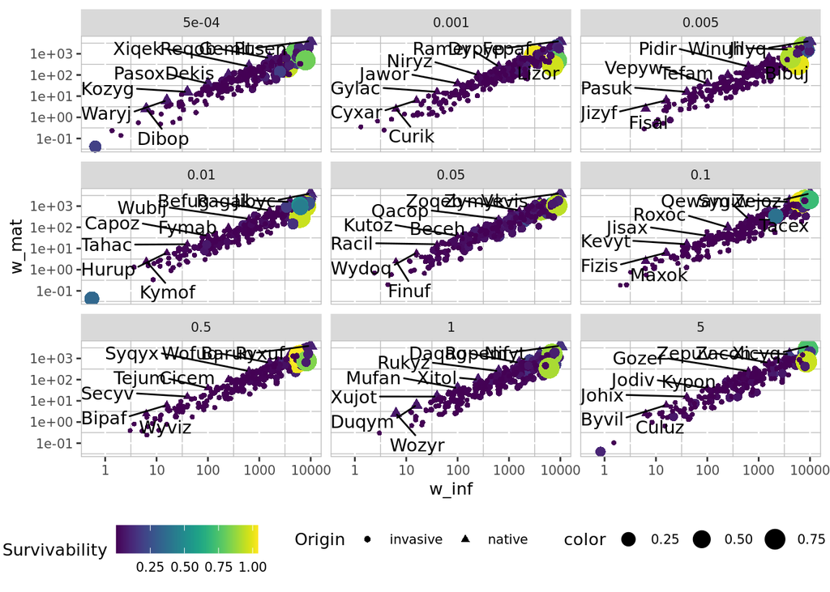

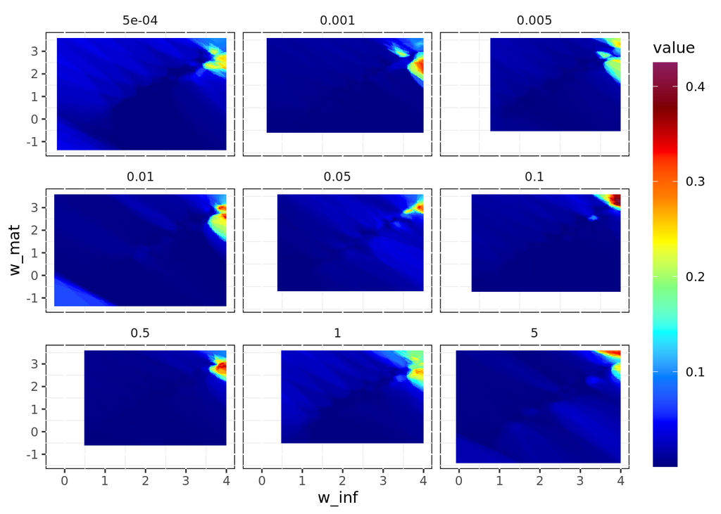

```r
plot_dat <- readRDS(paste0(folderName,"/survivalScore.rds"))
```

Figure 1: Asymptotic size versus maturation size of all species, faceted per kappa value. Color gradient is the survival score of the species. Dot size increases with survival score. Native species are denoted with a triangle and a name while invasive species have a disc.

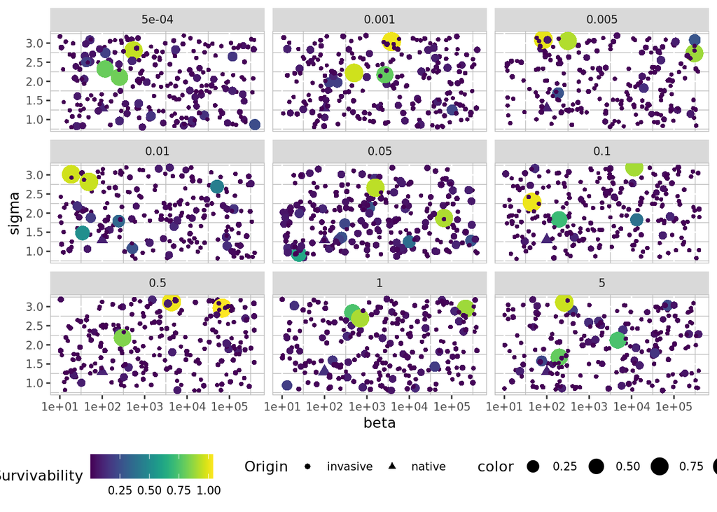

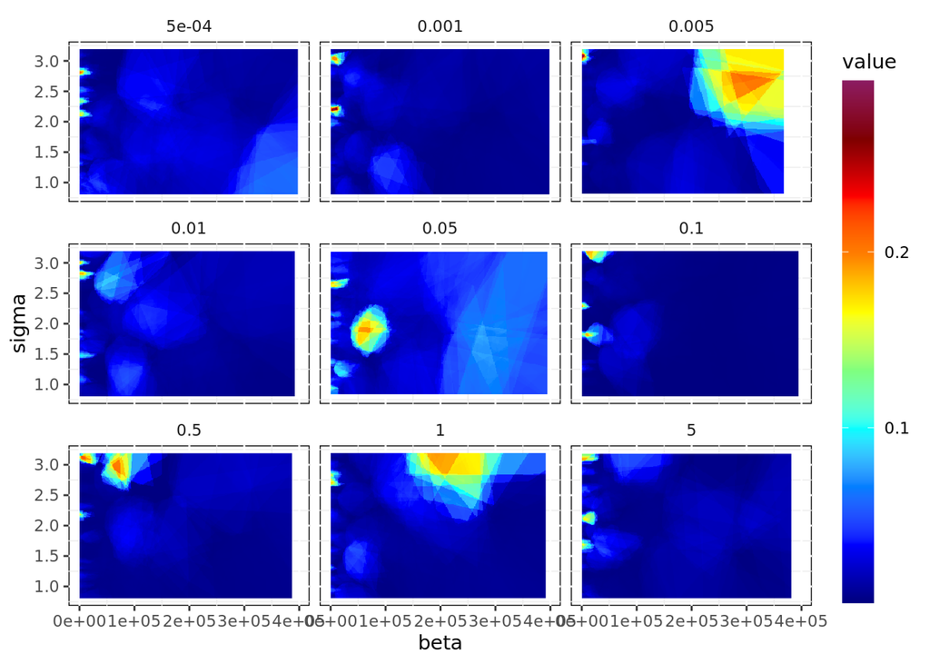

Figure 2: Beta versus sigma of all species, faceted per kappa value. Color gradient is the survival score of the species. Dot size increases with survival score. Native species are denoted with a triangle and invasive species with a disc.

In figure 2, there doesn’t seem to be any pattern worth mentionning.

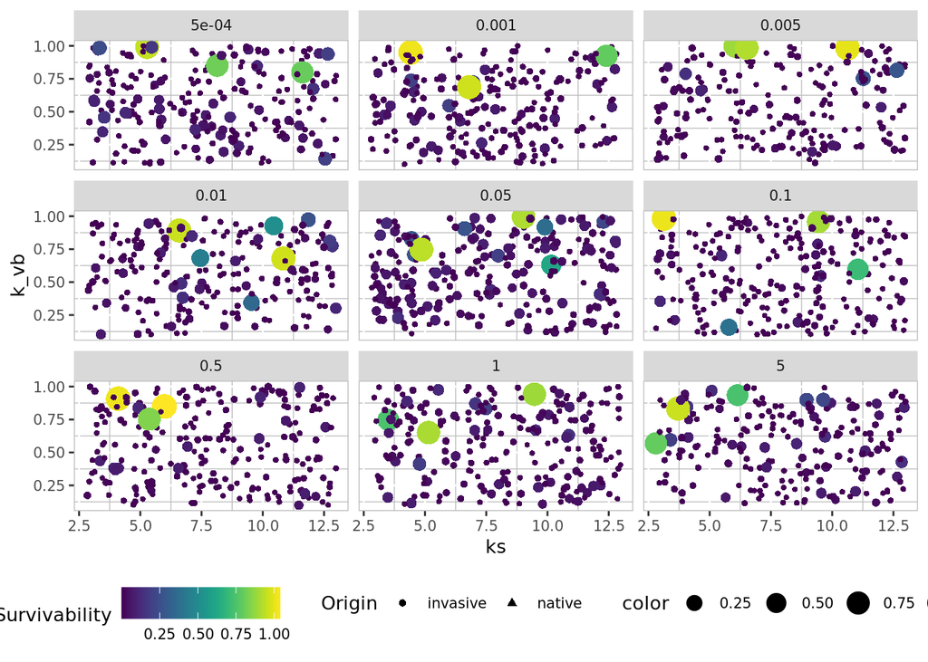

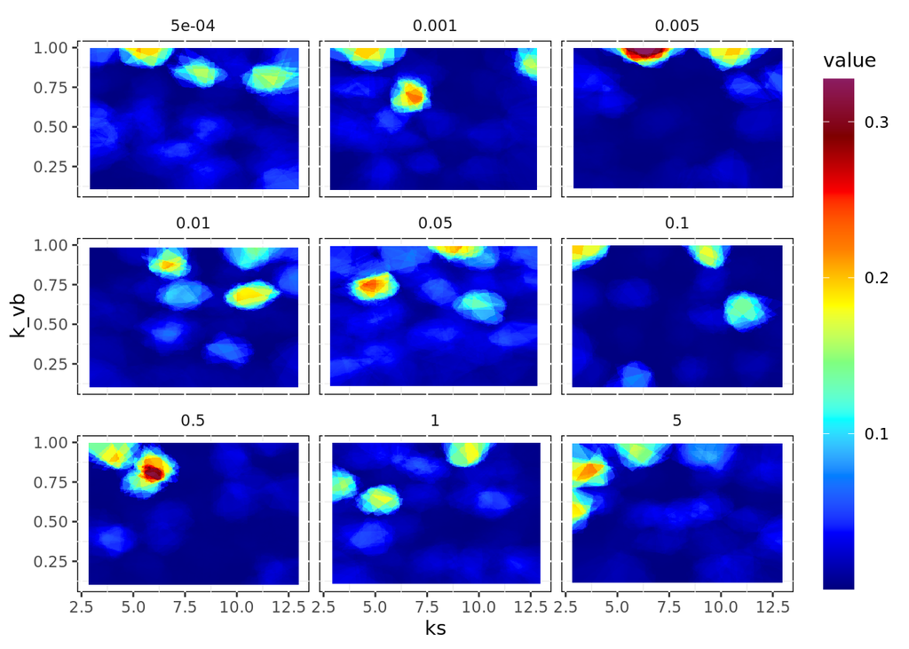

Figure 3: Metabolism coefficient versus von Bertalanffy parameter of all species, faceted per kappa value. Color gradient is the survival score of the species. Dot size increases with survival score. Native species are denoted with a triangle and invasive species with a disc.

In figure 3, higher survival score is correlated with higher k_vb and therefore faster growth. There doesn’t seem to be any kappa effect.

[figure not shown]

```r
a <- plot_biom[,6]

plot(a)

a[600:750]

sim1 <- readRDS("simulations/noRmax/kappa0.1/sim1.RDS")
sim2 <- readRDS("simulations/noRmax/kappa0.1/sim2.RDS")
sim3 <- readRDS("simulations/noRmax/kappa0.1/sim3.RDS")
```

In one of the simulations of kappa = 0.1, one of the species goes to 1e17 g and kills everything else. Keeping it just in case but it makes above plot look bad

### Comments

Here is the distribution in value of the survival score

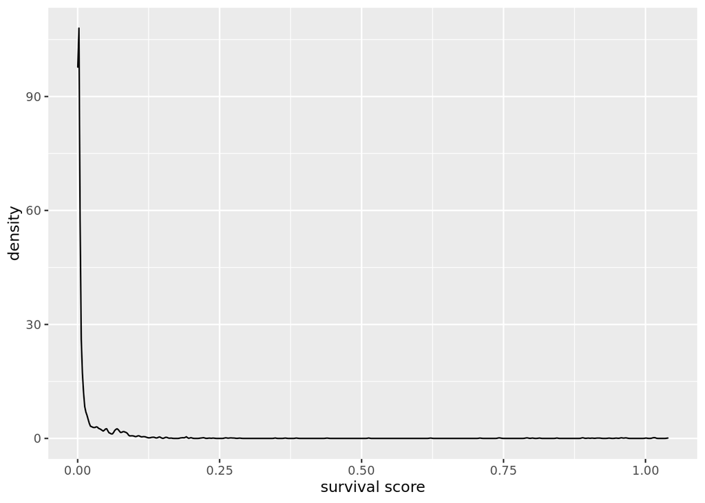

This explains the predominance of one color in the plots and it makes hard to see any patterns so I need better survival scores. It seems that the species surviving, all have a similar biomass and reproduction output.

Looking in more details at the number of invading species and their extinction

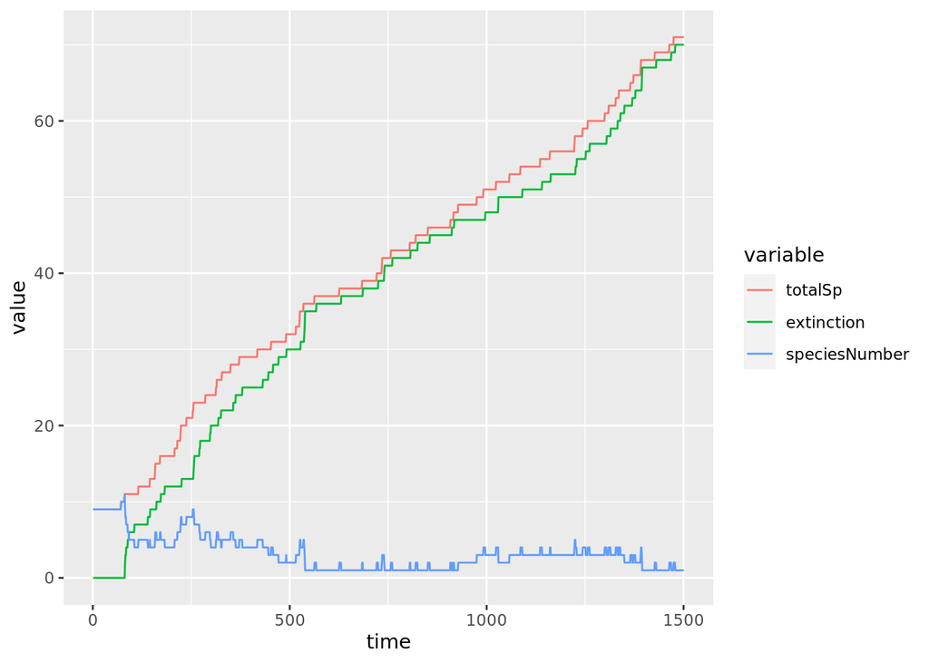

```r
sim <- readRDS(paste0(folderName,"/kappa0.5/sim1.RDS"))

plot_dat <- plotNoSp(sim, returnData = T)

plot_dat <- reshape2::melt(plot_dat, "time")

ggplot(plot_dat) +
  geom_line(aes(x = time, y = value, color = variable))
```

```r
# plotBiomass(sim)
```

Distribution of Rmax, maybe it has a role in so many species coexisting

[figure not shown]

```r
plot_dat <- readRDS(paste0(folderName,"/survivalScore.rds"))
plot_dat <- filter(plot_dat, color >= .001)

ggplot(plot_dat) +
  geom_point(aes(x = R_max, y = color)) +
  facet_wrap(~kappa) +
  scale_x_continuous(trans = "log10")
```

TODO

- reassess survival score